# Introduction to `scater`: Single-cell analysis toolkit for expression in R

Davis McCarthy

2015-04-17

This document gives an introduction to and overview of the functionality of the `scater` package.

The `scater` package is contains tools to help with the analysis of single-cell gene expression data, with the focus on RNA-seq data. The package features:

- A data structure for single-cell expression data;
- Functions for diagnostic plots for quality control;
- Methods for identifying cells at different stages of the cell cycle;
- Differential testing methods for finding genes with differences in behaviour between experimental conditions.

To get up and running as quickly as possible, see the Quick Start section below. For see the various in-depth sections on various aspects of the functionality that follow.

## Quick Start

Assuming you have a matrix containing expression count data summarised at the level of some features (gene, exon, region, etc.), then we first need to form an `SCESet` object containing the data. An `SCESet` object is the basic data container that we use in `scater`.

Here we use the example data provided with the package, which gives us two objects, a matrix of counts and a dataframe with information about the cells we are studying:

```r
library(scater)
data("sc_example_counts")
data("sc_example_cell_info")
ls()
```

[output not shown]

We use these objects to form an `SCESet` object containing all of the necessary information for our analysis:

```r
pd <- new("AnnotatedDataFrame", data = sc_example_cell_info)
example_sceset <- newSCESet(countData = sc_example_counts, phenoData = pd)
```

```
## Generating log2(counts-per-million) from counts to use as
##                 expression data, with prior.count = 1. See edgeR::cpm().
## Defining 'isExprs' using count data and a lower count
##                            threshold of 0
```

```r
example_sceset
```

```
## SCESet (storageMode: environment)
## assayData: 100 features, 40 samples
##   element names: counts, exprs, isExprs
## protocolData: none
## phenoData
##   sampleNames: A1 A2 ... H6 (40 total)
##   varLabels: Cell Mutation_Status Patient Library_Size
##   varMetadata: labelDescription
## featureData: none
## experimentData: use 'experimentData(object)'
## Annotation:
```

Subsetting is very convenient with this class. For example, we can filter out genes that are not expressed in any cells:

```r
keep_gene <- rowSums(isExprs(example_sceset)) > 0
example_sceset <- example_sceset[keep_gene,]
```

Now we have the expression data neatly stored in a structure that can be used for lots of exciting analyses.

## The SCESet class

In `scater` we organise single-cell expression data in objects of the `SCESet` class. The class is derived from the Bioconductor `ExpressionSet` class, which provides a common interface familiar to those who have analyzed microarray experiments with Bioconductor. The class requires three input files: 1. `exprs`, a numeric matrix of expression values, where rows are genes, and columns are cells 2. `phenoData`, an `AnnotatedDataFrame` object, where rows are cells, and columns are cell attributes (such as cell type, culture condition, day captured, etc.) 3. `featureData`, an `AnnotatedDataFrame` object, where rows are features (e.g. genes), and columns are gene attributes, such as biotype, gc content, etc.

The requirements for the `SCESet` class (as with other S4 classes in R and Bioconductor) are strict. The idea is that strictness with generating a valid class object ensures that downstream methods applied to the class will work reliably. Thus, the expression value matrix *must* have the same number of columns as the `phenoData` object has rows, and it must have the same number of rows as the `featureData` dataframe has rows. Row names of the `phenoData` object need to match the column names of the expression matrix. Row names of the `featureData` object need to match row names of the expression matrix.

You can create a new `SCESet` object using count data as follows. In this case, the `exprs` slot in the object will be generated as log2(counts-per-million) using the `cpm` function from `edgeR`, with a “prior count” value of 1:

```r
pd <- new("AnnotatedDataFrame", data = sc_example_cell_info)
gene_df <- data.frame(Gene = rownames(sc_example_counts))
rownames(gene_df) <- gene_df$Gene
fd <- new("AnnotatedDataFrame", data = gene_df)
example_sceset <- newSCESet(countData = sc_example_counts, phenoData = pd,
                            featureData = fd)
```

```
## Generating log2(counts-per-million) from counts to use as
##                 expression data, with prior.count = 1. See edgeR::cpm().
## Defining 'isExprs' using count data and a lower count
##                            threshold of 0
```

```r
example_sceset
```

```
## SCESet (storageMode: environment)
## assayData: 100 features, 40 samples
##   element names: counts, exprs, isExprs
## protocolData: none
## phenoData
##   sampleNames: A1 A2 ... H6 (40 total)
##   varLabels: Cell Mutation_Status Patient Library_Size
##   varMetadata: labelDescription
## featureData
##   featureNames: Gene_001 Gene_002 ... Gene_100 (100 total)
##   fvarLabels: Gene
##   fvarMetadata: labelDescription
## experimentData: use 'experimentData(object)'
## Annotation:
```

We can also make an `SCESet` object with just a matrix of expression values (no count data required) like this:

```r
example2 <- newSCESet(cellData = edgeR::cpm.default(sc_example_counts))
```

```
## Defining 'isExprs' using cellData and a lower count
##                            threshold of 0
```

```r
pData(example2)
```

```
## data frame with 0 columns and 40 rows
```

```r
fData(example2)
```

```
## data frame with 0 columns and 100 rows
```

We have accessor functions to access elements of the `SCESet` object:

- `counts(object)`: returns the matrix of read counts. As you can see above, if no counts are defined for the object, then the counts matrix still exists, but is populated with `NA`.

```r
counts(example2)[1:3, 1:6]
```

```
##          A1 A2 A3 A4 A5 A6
## Gene_001 NA NA NA NA NA NA
## Gene_002 NA NA NA NA NA NA
## Gene_003 NA NA NA NA NA NA
```

- `exprs(object)`: returns the matrix of gene expression values. Typically these should be log2(counts-per-million) values or log2(reads-per-kilobase-per-million-mapped), appropriately normalised of course. The package will generally assume that these are the values to use for expression.

```r
exprs(example2)[1:3, 1:6]
```

```
##                  A1        A2          A3       A4          A5         A6
## Gene_001   118.4273  2262.785    60.75334     0.00     0.00000     0.0000
## Gene_002     0.0000     0.000     0.00000 33696.97    51.23213   105.7082
## Gene_003 35409.7584 25946.598 51458.08019 18909.09 23771.70962 38477.8013
```

- `isExprs(object)`: returns a logical matrix indicating whether each gene expression observation is above the defined `lowerDetectionLimit` (default is 0). This can be determined on the count scale or the “expression” (i.e. `exprs(object)`) scale.

```r
isExprs(example2)[1:3, 1:6]
```

```
##             A1    A2    A3    A4    A5    A6
## Gene_001  TRUE  TRUE  TRUE FALSE FALSE FALSE
## Gene_002 FALSE FALSE FALSE  TRUE  TRUE  TRUE
## Gene_003  TRUE  TRUE  TRUE  TRUE  TRUE  TRUE
```

It is straight-forward to change the threshold by which we decide which observations are expressed or not:

```r
isExprs(example2) <- calcIsExprs(example2, lowerDetectionLimit = 0.5,
                               expr_data = "exprs")
isExprs(example2)[1:3, 1:6]
```

```
##             A1    A2    A3    A4    A5    A6
## Gene_001  TRUE  TRUE  TRUE FALSE FALSE FALSE
## Gene_002 FALSE FALSE FALSE  TRUE  TRUE  TRUE
## Gene_003  TRUE  TRUE  TRUE  TRUE  TRUE  TRUE
```

If you later find some count data that you want to add to the `SCESet` object (always worth checking down the back of the couch), then you can add it easily:

```r
counts(example2) <- sc_example_counts
example2
```

```
## SCESet (storageMode: environment)
## assayData: 100 features, 40 samples
##   element names: counts, exprs, isExprs
## protocolData: none
## phenoData: none
## featureData: none
## experimentData: use 'experimentData(object)'
## Annotation:
```

```r
counts(example2)[1:3, 1:6]
```

```
##           A1  A2  A3  A4  A5  A6
## Gene_001   1  15   1   0   0   0
## Gene_002   0   0   0 139   1   1
## Gene_003 299 172 847  78 464 364
```

Handily, it is also easy to replace other data in slots of the `SCESet` object using generic accessor and replacement functions.

```r
gene_df <- data.frame(Gene = rownames(sc_example_counts))
rownames(gene_df) <- gene_df$Gene
fd <- new("AnnotatedDataFrame", data = gene_df)
## replace featureData
fData(example_sceset) <- fd
## replace phenotype data
pData(example_sceset) <- pd
## replace expression data to be used
exprs(example_sceset) <- edgeR::cpm.default(counts(example_sceset),
                                            prior.count = 5, log = TRUE)
```

## Plots of expression values

In `scater`, the `plotExpression` function makes it easy to plot expression values for a subset of genes or features. This can be particularly useful when investigating the some genes identified as being of interest from differential expression testing or other means.

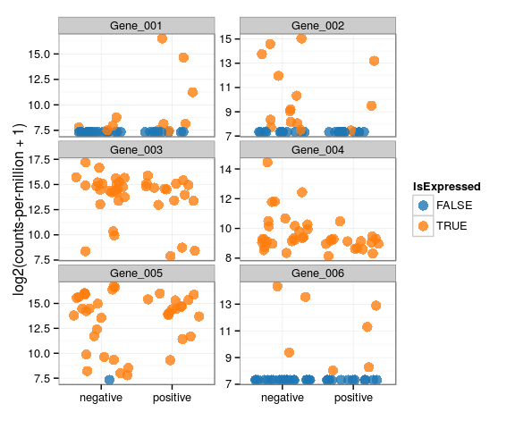

```r
plotExpression(rownames(example_sceset)[1:6], example_sceset,
               aes(x = Mutation_Status, y = log2_evals, colour = IsExpressed))
```

This function uses `ggplot2`, making it easy to change the theme to whatever you prefer. We can also show the median expression level per group on the plot and show a violin plot to summarise the distribution of expression values:

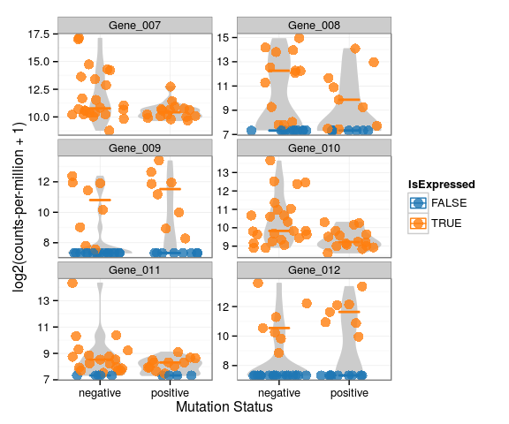

```r
theme_set(theme_bw())
plotExpression(rownames(example_sceset)[7:12], example_sceset,
               aes(x = Mutation_Status, y = log2_evals, colour = IsExpressed),
                   show_median = TRUE, show_violin = TRUE,
               xlab="Mutation Status")
```

## Quality control

The `scater` package puts a focus on aiding with quality control (QC) and pre-processing of single-cell RNA-seq data before further downstream analysis.

### Calculate QC metrics

To compute commonly-used QC metrics we have the function `calculateQCMetrics()`:

```r
names(pData(example_sceset))
```

```
## [1] "Cell"            "Mutation_Status" "Patient"         "Library_Size"
```

```r
example_sceset <- calculateQCMetrics(example_sceset, control_genes=NULL)
names(pData(example_sceset))
```

```
##  [1] "Cell"
##  [2] "Mutation_Status"
##  [3] "Patient"
##  [4] "Library_Size"
##  [5] "depth"
##  [6] "log10_depth"
##  [7] "coverage"
##  [8] "filter_on_depth"
##  [9] "filter_on_coverage"
## [10] "reads_from_control_genes"
## [11] "log10_reads_from_control_genes"
## [12] "reads_from_biological_genes"
## [13] "log10_reads_from_biological_genes"
## [14] "pct_reads_from_control_genes"
```

This function adds the following columns to `pData(object)`:

- `depth`: total number of reads for the cell (aka ‘library size’)
- `log10_depth`: depth on the log10-scale
- `coverage`: the number of genes for the cell that have expression above the detection limit (default detection limit is zero)
- `filter_on_depth`: would this cell be filtered out based on its log10-depth being (by default) more than 5 median absolute deviations from the median log10-depth for the dataset?
- `filter_on_coverage`: would this cell be filtered out based on its coverage being (by default) more than 5 median absolute deviations from the median coverage for the dataset?
- `reads_from_control_genes`: total number of reads for the cell that come from (a set of user-defined) control genes. Defaults to zero if no control genes are indicated.
- `reads_from_biological_genes`: total number of reads for the cell that come from biological genes (i.e. not control genes). Defaults to `depth` if no control genes are indicated.
- `log10_reads_from_control_genes`: total number of reads from control genes on the log10-scale. Defaults to zero (i.e. log10(0 + 1), offset to avoid infinite values) if no control genes are indicated.
- `log10_reads_from_biological_genes`: total number of reads from biological genes on the log10-scale. Defaults to zero (i.e. log10(0 + 1), offset to avoid infinite values) if no control genes are indicated. *`pct_reads_from_control_genes`: percentage of all reads that come from the defined control genes. Defaults to zero if no control genes are defined.

The function further adds the following columns to `fData(object)`:

- `mean_exprs`: the mean expression level of the gene/feature.
- `exprs_rank`: the rank of the gene’s expression level in the cell.
- `total_gene_reads`: the total number of reads mapped to that gene across all cells.
- `log10_total_gene_reads`: total gene reads on the log10-scale.
- `prop_total_reads`: the proportion of all reads that are accounted for by the reads mapping to the gene.
- `is_control_gene`: is the gene a control gene? Default is `FALSE` unless control genes are defined by the user. `n_cells_exprs`: the number of cells for which the expression level of the gene is above the detection limit (default detection limit is zero).

### Produce diagnostic plots for QC

Visualising the data and metadata in various ways can be very helpful for QC. We have a small suite of plotting functions to produce diagnostic plots for: 1. Plotting the most expressed genes across the dataset. 2. Finding the most important principal components for a given cell phenotype or metadata variable (from `pData(object)`). 3. Plotting a set of cell phenotype/metadata variables against each other and calculating the (marginal) percentage of gene expression variance that they explain.

These three QC plots can all be accessed through the function `plotQC` (we need to make sure there are no genes with zero or constant expression):

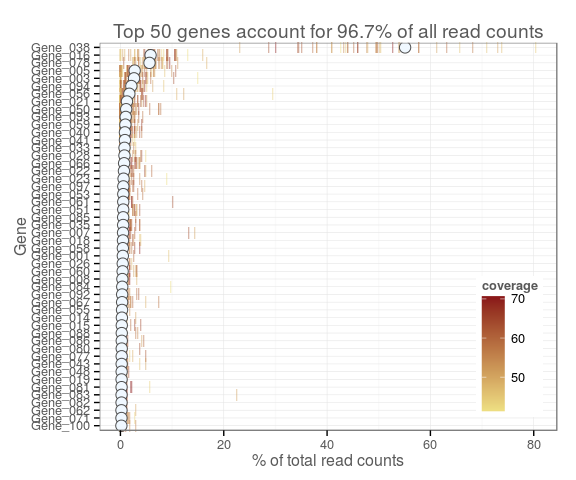

[figure not shown]

```r
keep_gene <- rowSums(isExprs(example_sceset)) > 0
example_sceset <- example_sceset[keep_gene,]
## Plot QC
plotQC(example_sceset, type="most-expressed")
```

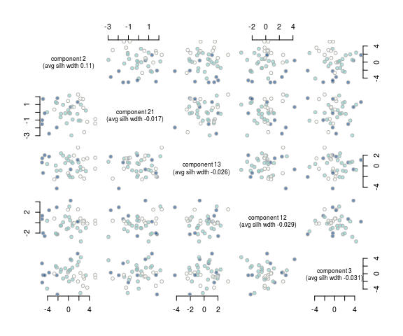

```r
plotQC(example_sceset, type="find-pcs", variable="coverage")
```

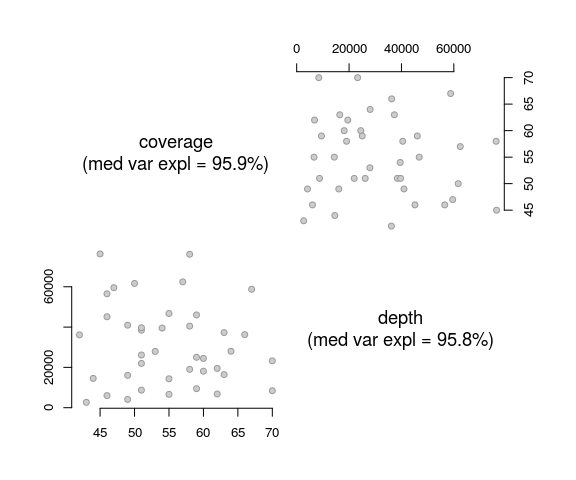

```r
plotQC(example_sceset, type="expl", variable=c("coverage", "depth"))
```

In this small dataset depth and coverage explain a very large proportion of the variance in gene expression. The proportion of variance that they explain for a real dataset should be much smaller (say 1-5%).

We also have neat functions to plot two cell metadata variables:

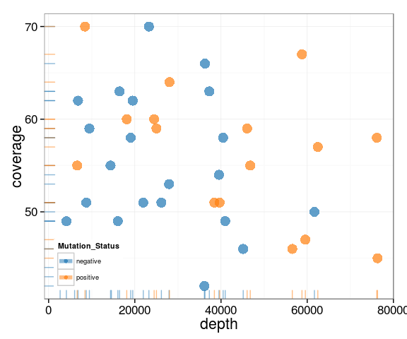

```r
plotPhenoData(example_sceset, aes(x=depth, y=coverage, colour=Mutation_Status))
```

and to plot two feature metadata variables:

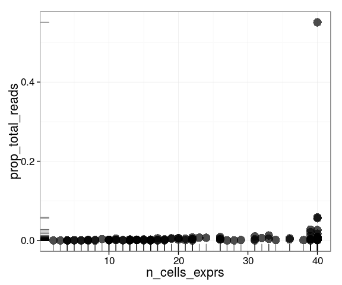

```r
plotFeatureData(example_sceset, aes(x=n_cells_exprs, y=prop_total_reads))
```

These sorts of plots can be very useful for finding potentially problematic cells and genes, as well as identifying important sources of variation in the data.

The output of these functions is a `ggplot` object, which can be added to, amended and altered. For example, if we don’t like the legend position in the Coverage vs Depth plot above, we can change it:

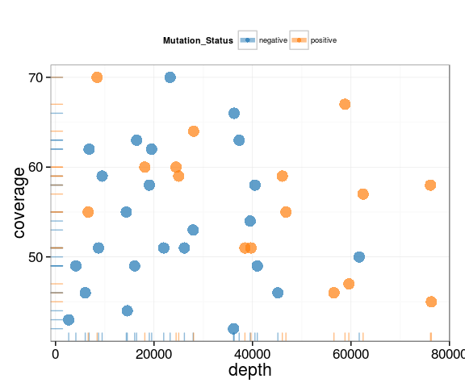

```r
plotPhenoData(example_sceset, aes(x=depth, y=coverage, colour=Mutation_Status)) +
    theme(legend.position="top")
```

We could also add a trend line for each group:

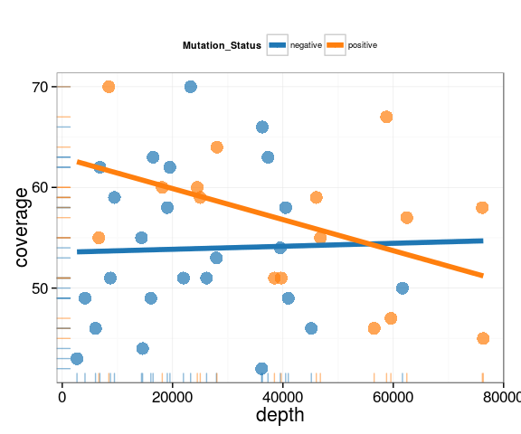

```r
plotPhenoData(example_sceset, aes(x=depth, y=coverage, colour=Mutation_Status)) +
    theme(legend.position="top") +
    stat_smooth(method="lm", se=FALSE, size=2, fullrange=TRUE)
```

Tapping into the powerful capabilities of `ggplot2`, the possibilities are many.

Combined with the excellent subsetting capabilities of the `SCESet` class, we have convenient tools for conducting QC and pre-processing (e.g. filtering) data for downstream analysis.